## **DATA 645. Neural Networks and Deep Learning**

## Module 4. Homework Lab

# **Method of Gradient Descent**

### Gradient Descent

##### While we focus on backpropagation and gradient descent in detail next week, let us practice the network training by gradient descent now, using our Reading Materials for this week.

Generate linear-looking data using, for example, the Python code in the Lab helper in reading materials.

1. Implement gradient descent for the MSE cost function with a fixed learning rate and 1000 iterations. Try three different learning rates 0.02, 0.1, 0.5 and show the effect of the learning rate in the convergence behavior of the algorithm. For this, you can plot the first 10 steps of gradient descent for each of the learning rates. Which learning rate provides the fastest convergence?
2. Implement stochastic gradient descent. Try different learning schedule hyper-parameters, and a random initialization. Show the first 20 steps of stochastic gradient descent. What do you observe?
3. Implement mini-batch gradient descent with mini-batch size equal to 20 and plot the fist 20 steps of mini-bath gradient descent.
4. Compare stochastic gradient descent, gradient descent, and mini-batch gradient descent in terms of the paths taken by the three gradient descent algorithms in the parameter space during training. What do you observe? Which algorithm shows faster convergence?

# Generate linear-looking data using, for example, the Python code in the Lab helper in reading materials.

```python
import numpy as np

%matplotlib inline
import matplotlib as mpl
import matplotlib.pyplot as plt
mpl.rc('axes', labelsize=14)
mpl.rc('xtick', labelsize=12)
mpl.rc('ytick', labelsize=12)

np.random.seed(123)

X = 2 * np.random.rand(100, 1)
y = 4 + 3 * X + np.random.randn(100, 1)
```

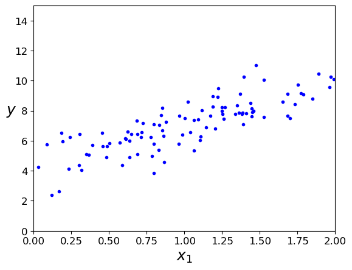

```python
plt.plot(X, y, "b.")
plt.xlabel("$x_1$", fontsize=18)
plt.ylabel("$y$", rotation=0, fontsize=18)
plt.axis([0, 2, 0, 15])
plt.show()

# Add intercept terms

X_b = np.c_[np.ones((100, 1)), X]  # add x0 = 1 to each instance

X_new = np.array([[0], [2]])
X_new_b = np.c_[np.ones((2, 1)), X_new]  # add x0 = 1 to each instance
```

```python
# MSE Cost Function

def mse_cost_function(theta):
    """
    theta is a length-2 vector [theta0, theta1]
    MSE = (1/m) * sum((X_b @ theta - y)^2)
    """
    theta = theta.reshape(2, 1)           # ensure shape (2,1)
    errors = X_b @ theta - y              # shape (100,1)
    return float((errors.T @ errors) / len(y))  # scalar

def gradient_descent(initial_guess, learning_rate, num_iterations):
    trajectory = []   # Store theta values for plotting
    cost = []        # Store MSE for each iteration

    current_point = np.array(initial_guess, dtype=float).reshape(2, 1)

    for iteration in range(num_iterations):
        trajectory.append(current_point.copy())
        cost.append(mse_cost_function(current_point))

        # Using MSE
        m = len(y)
        gradient = (2/m) * (X_b.T @ (X_b @ current_point - y))

        # same update rule form: point = point - lr * gradient
        current_point = current_point - learning_rate * gradient

    return np.array(trajectory), np.array(cost), current_point
```

# 1.a.1 Implement gradient descent for the MSE cost function with a fixed learning rate and 1000 iterations with a learning rate of 0.02.

```python
initial_guess = [10, 10]
learning_rate = 0.02
num_iterations = 1000

# Run gradient descent and store the trajectory
trajectory, cost, theta_final = gradient_descent(initial_guess, learning_rate, num_iterations)
```

# 1.a.2 Plot the first 10 steps of gradient descent (lr = 0.02)

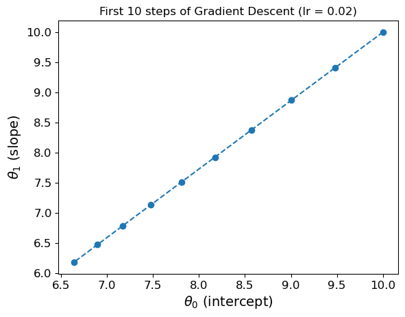

```python
first10 = trajectory[:10, :, 0]  # convert from shape (10,2,1) -> (10,2)

plt.figure()
plt.plot(first10[:, 0], first10[:, 1], marker='o', linestyle='dashed')
plt.xlabel(r"$\theta_0$ (intercept)")
plt.ylabel(r"$\theta_1$ (slope)")
plt.title("First 10 steps of Gradient Descent (lr = 0.02)")
plt.show()
```

# 1.a.3 Plot the convergence (lr = 0.02)

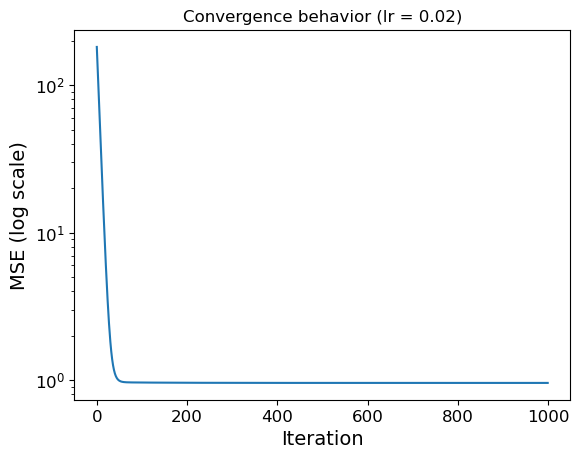

```python
plt.figure()
plt.plot(cost)
plt.yscale("log")
plt.xlabel("Iteration")
plt.ylabel("MSE (log scale)")
plt.title("Convergence behavior (lr = 0.02)")
plt.show()
```

# 1.b.1 Implement gradient descent for the MSE cost function with a fixed learning rate and 1000 iterations with a learning rate of 0.1.

```python
initial_guess = [10, 10]
learning_rate = 0.1
num_iterations = 1000

# Run gradient descent and store the trajectory
trajectory, cost, theta_final = gradient_descent(initial_guess, learning_rate, num_iterations)
```

# 1.b.2 Plot the first 10 steps of gradient descent (lr = 0.1)

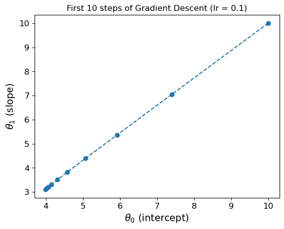

```python
first10 = trajectory[:10, :, 0]  # convert from shape (10,2,1) -> (10,2)

plt.figure()
plt.plot(first10[:, 0], first10[:, 1], marker='o', linestyle='dashed')
plt.xlabel(r"$\theta_0$ (intercept)")
plt.ylabel(r"$\theta_1$ (slope)")
plt.title("First 10 steps of Gradient Descent (lr = 0.1)")
plt.show()
```

# 1.b.3 Plot the convergence (lr = 0.1)

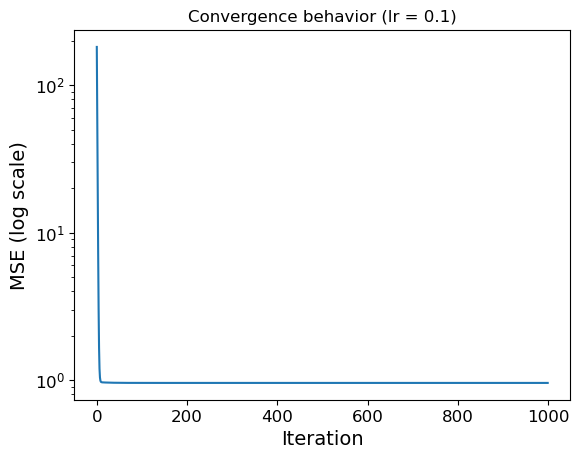

```python
plt.figure()
plt.plot(cost)
plt.yscale("log")
plt.xlabel("Iteration")
plt.ylabel("MSE (log scale)")
plt.title("Convergence behavior (lr = 0.1)")
plt.show()
```